# Diagrammes en barres et graphiques à nuage de points

- Lire 'fandango_scores.csv' dans un dataframe reviews.
- Sélectionner les colonnes suivantes et assigner les au dataframe norm_reviews:
  > - 'FILM'
  > - 'RT_user_norm'
  > - 'Metacritic_user_nom'
  > - 'IMDB_norm'
  > - 'Fandango_Ratingvalue'
  > - 'Fandango_Stars'
- Afficher les premières lignes de norm_reviews.

```python
import pandas as pd
reviews = pd.read_csv("fandango_scores.csv")
cols = ['FILM', 'RT_user_norm', 'Metacritic_user_nom', 'IMDB_norm', 'Fandango_Ratingvalue', 'Fandango_Stars']
norm_reviews = reviews[cols]
print(norm_reviews[:3])
```

```
                             FILM  RT_user_norm  Metacritic_user_nom  \
0  Avengers: Age of Ultron (2015)           4.3                 3.55
1               Cinderella (2015)           4.0                 3.75
2                  Ant-Man (2015)           4.5                 4.05

   IMDB_norm  Fandango_Ratingvalue  Fandango_Stars
0       3.90                   4.5             5.0
1       3.55                   4.5             5.0
2       3.90                   4.5             5.0
```

## Diagrammes en barre

- Créer un sous-graphique et assigner l'objet Figure à la variable fig et l'objet Axes à la variable ax.
- Générer un diagramme en barre avec:
  > - left définie par bar_positions qui doit prendre les valeurs 1,2,3,4 et 5
  > - height définie par bar_heights qui doit prendre les 5 colonnes qui nous intéressent
  > - width fixé à 0.5
- Utiliser plt.show() pour afficher le diagramme en barre.

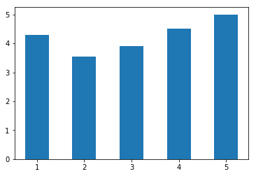

```python
import matplotlib.pyplot as plt
from numpy import arange

num_cols = ['RT_user_norm', 'Metacritic_user_nom', 'IMDB_norm', 'Fandango_Ratingvalue', 'Fandango_Stars']

bar_heights = norm_reviews[num_cols].iloc[0].values
bar_positions = arange(5) + 1

fig, ax = plt.subplots()
ax.bar(bar_positions, bar_heights, 0.5)
plt.show()
```

## Aligner l'intitulé et le trait sur l'axe x

- Créer un sous-graphique et assigner l'objet Figure à la variable fig et l'objet Axes à la variable ax.
- Générer un diagramme en barre avec:
  > - left définie par bar_positions qui doit prendre les valeurs 1, 2, 3, 4 et 5
  > - height définie par bar_heights qui doit prendre les 5 colonnes qui nous intéressent
  > - width fixé à 0.5
- Placer les 5 traits correspondant aux barres.
- Placer les intitulés de num_cols et faire une rotation de 90 degrés.
- Définir l'axe x par 'Sources de notation'.
- Définir l'axe y par 'Note moyenne'.
- Définir le titre par 'Moyenne des notes utilisateurs pour le film Avengers: Age of Ultron (2015'.
- Utiliser plt.show() pour afficher le diagramme.

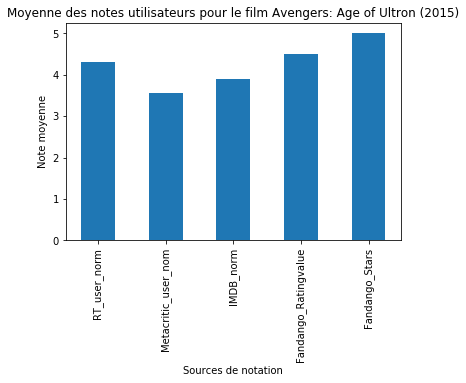

```python
num_cols = ['RT_user_norm', 'Metacritic_user_nom', 'IMDB_norm', 'Fandango_Ratingvalue', 'Fandango_Stars']
bar_heights = norm_reviews[num_cols].iloc[0].values
bar_positions = arange(5) + 1
tick_positions = range(1,6)

fig, ax = plt.subplots()
ax.bar(bar_positions, bar_heights, 0.5)
ax.set_xticks(tick_positions)
ax.set_xticklabels(num_cols,rotation=90)

ax.set_xlabel('Sources de notation')
ax.set_ylabel('Note moyenne')
ax.set_title('Moyenne des notes utilisateurs pour le film Avengers: Age of Ultron (2015)')

plt.show()
```

## Diagramme en barres horizontales

- Créer un sous-graphique et assigner l'objet Figure à la variable fig et l'objet Axes à la variable ax.
- Générer un diagramme en barres avec:
  > - bottom pour les positions bar_positions
  > - width pour la largeur des barres bar_widths
  > - height fixé à 0.5
- Placer les 5 traits correspondants aux barres sur l'axe y.
- Placer les intitulés de num_cols.
- Définir l'axe y par 'Sources de notes'.
- Définir l'axe x par 'Note moyenne'.
- définir le titre par 'Note moyenne utilisateurs pour le film Avengers: Age of Ultron (2015)'.
- Utiliser plt.show() pour afficher le diagramme en barre.

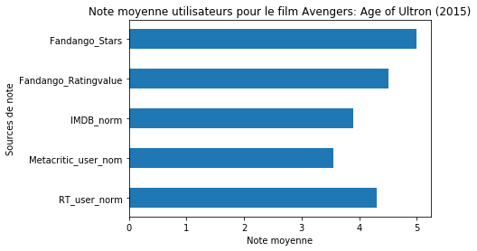

```python
import matplotlib.pyplot as plt
from numpy import arange
num_cols = ['RT_user_norm', 'Metacritic_user_nom', 'IMDB_norm', 'Fandango_Ratingvalue', 'Fandango_Stars']

bar_widths = norm_reviews[num_cols].iloc[0].values
bar_positions = arange(5) + 1
tick_positions = range(1,6)
fig, ax = plt.subplots()

ax.barh(bar_positions, bar_widths, 0.5)

ax.set_yticks(tick_positions)
ax.set_yticklabels(num_cols)
ax.set_ylabel('Sources de note')
ax.set_xlabel('Note moyenne')
ax.set_title('Note moyenne utilisateurs pour le film Avengers: Age of Ultron (2015)')

plt.show()
```

## Graphique à nuage de points

- Créer un sous-graphique et assigner l'objet Figure à la variable fig et l'objet Axes à la variable ax.
- Générer un graphique à nuage de points avec la colonne 'Fandango_Ratingvalue' sur l'axe x et et la colonne 'RT_user_norm' pour l'axe y.
- Définir pour l'axe x 'Fandango' et 'Rotten Tomatoes' pour l'axe y.
- Afficher le graphique résultant.

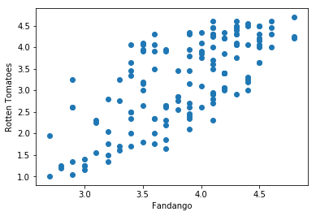

```python
fig, ax = plt.subplots()
ax.scatter(norm_reviews['Fandango_Ratingvalue'], norm_reviews['RT_user_norm'])
ax.set_xlabel('Fandango')
ax.set_ylabel('Rotten Tomatoes')
plt.show()
```

## Intervertir les axes

- Pour le sous-graphique associé à la variable ax1.
  > - Générer un graphique à nuage de points avec la colonne 'Fandango_Ratingvalue' sur l'axe x et la colonne 'RT_user_norm' sur l'axe y
  > - Définir pour l'axe x 'Fandango' et pour l'axe y 'Rotten Tomatoes'
- Pour le sous-graphique associé à la variable ax2.
  > - Générer un graphique à nuage de points avec la colonne 'RT_user_norm' sur l'axe x et la colonne 'Fandango_Ratingvalue' sur l'axe y
  > - Définir pour l'axe x 'Rotten Tomatoes' et pour l'axe y 'fandango'
- Afficher le graphique résultant.

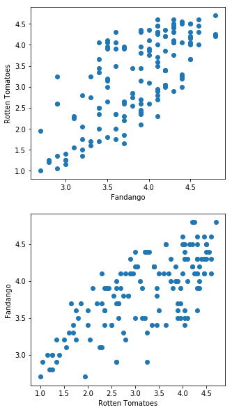

```python
fig = plt.figure(figsize=(5,10))
ax1 = fig.add_subplot(2,1,1)
ax2 = fig.add_subplot(2,1,2)

ax1.scatter(norm_reviews['Fandango_Ratingvalue'], norm_reviews['RT_user_norm'])
ax1.set_xlabel('Fandango')
ax1.set_ylabel('Rotten Tomatoes')

ax2.scatter (norm_reviews['RT_user_norm'], norm_reviews['Fandango_Ratingvalue'])
ax2.set_xlabel('Rotten Tomatoes')
ax2.set_ylabel('Fandango')

plt.show()
```

## Comparaison de corrélations

Tracer un graphiques avec 3 sous-graphiques:

- Pour le sous-graphique associé à la variable ax1:
  > - Générer un graphique à nuage de points avec la colonne 'Fandango_Ratingvalue' sur l'axe x et la colonne 'RT_user_norm' sur l'axe y
  > - Définir pour l'axe x 'Fandango' et pour l'axe y 'Rotten Tomatoes'
  > - Définir les limites des axes x et y en les fixant de 0 à 5
- Pour le sous-graphique associé à la variable ax2:
  > - Générer un graphique à nuage de points avec la colonne 'Fandango_Ratingvalue' sur l'axe x et la colonne 'Metacritic_user_nom' sur l'axe y
  > - Définir pour l'axe x 'Fandango' et pour l'axe y 'Metacritic'
  > - Définir les limites des axes x et y en les fixant de 0 à 5
- Pour le sous-graphique associé à la variable ax3:
  > - Générer un graphique à nuage de points avec la colonne 'Fandango_Ratingvalue' sur l'axe x et la colonne 'IMDB_norm' sur l'axe y
  > - Définir pour l'axe x 'Fandango' et pour l'axe y 'IMDB'
  > - Définir les limites des axes x et y en les fixant de 0 à 5
- Afficher le graphique.

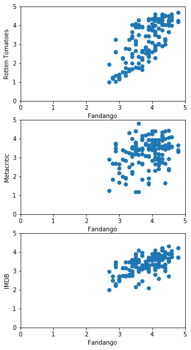

```python
import matplotlib.pyplot as plt

fig = plt.figure(figsize=(5,10))

ax1 = fig.add_subplot(3,1,1)
ax2 = fig.add_subplot(3,1,2)
ax3 = fig.add_subplot(3,1,3)

ax1.scatter(norm_reviews['Fandango_Ratingvalue'], norm_reviews['RT_user_norm'])
ax1.set_xlabel('Fandango')
ax1.set_ylabel('Rotten Tomatoes')
ax1.set_xlim(0,5)
ax1.set_ylim(0,5)

ax2.scatter(norm_reviews['Fandango_Ratingvalue'], norm_reviews['Metacritic_user_nom'])
ax2.set_xlabel('Fandango')
ax2.set_ylabel('Metacritic')
ax2.set_xlim(0,5)
ax2.set_ylim(0,5)

ax3.scatter(norm_reviews['Fandango_Ratingvalue'], norm_reviews['IMDB_norm'])
ax3.set_xlabel('Fandango')
ax3.set_ylabel('IMDB')
ax3.set_xlim(0,5)
ax3.set_ylim(0,5)

plt.show()
```